# Ariadne auf Naxos - Die Hamburgische Staatsoper

[figure not shown]

Monika Rittershaus

[Programm](https://www.die-hamburgische-staatsoper.de/de/programm/) → Oper

# Ariadne auf Naxos

Richard Strauss

Inszenierung von 2025

- So 16.11. 19:00 Tickets
- Fr 21.11. 19:00 Tickets
- Fr 28.11. 19:00 Tickets
- Zum letzten Mal in dieser Spielzeit

  Do 4.12. 19:00 Tickets

Kurz vor der Erstaufführung eines von ihm beauftragten neuen Musiktheaterwerks ordnet ein Kunstmäzen an, zugleich das Stück einer Komödiantengruppe zu spielen. Der Komponist ist außer sich, kann die Verstrickung der beiden Aufführungen allerdings nicht verhindern. Im Satyrspiel der Strauss-Trilogie von Regisseur Dmitri Tcherniakov konkurrieren nicht nur zwei Liebes-, sondern auch zwei Lebensmodelle auf humorvolle, aber auch bitterernste Weise.

## „Das Zuhören ist der reinste Genuss!“ NDR kultur

Oper in einem Aufzug nebst einem Vorspiel  
Komposition: Richard Strauss  
Libretto: Hugo von Hofmannsthal

- 1916 4. Oktober, Uraufführung an der Hofoper Wien
- 2025 26. Januar, Premiere dieser Inszenierung an der Hamburgischen Staatsoper
- 2025 Gespräch: Am 4. Dezember 2025 findet nach der Vorstellung im Vorderhaus der Hamburgischen Staatsoper das Gespräch „Ästhetik: Naturalismus auf der Opernbühne“ zwischen Dr. Laura Schmidt, Prof. Sabina Dhein und Prof. David Hermann statt.

[interactive chart not shown]

## Besetzung

- Musikalische Leitung

  [Johannes Debus](https://www.die-hamburgische-staatsoper.de/de/personen/4015-johannes-debus)
- Inszenierung

  [Dmitri Tcherniakov](https://www.die-hamburgische-staatsoper.de/de/personen/39912446-dmitri-tcherniakov)
- Kostüme

  [Elena Zaytseva](https://www.die-hamburgische-staatsoper.de/de/personen/39912529-elena-zaytseva)
- Licht

  [Gleb Filshtinsky](https://www.die-hamburgische-staatsoper.de/de/personen/39912528-gleb-filshtinsky)
- Dramaturgie

  [Tatiana Werestchagina](https://www.die-hamburgische-staatsoper.de/de/personen/39913399-tatiana-werestchagina)

  [Angela Beuerle](https://www.die-hamburgische-staatsoper.de/de/personen/1968-angela-beuerle)

  [Michael Sangkuhl](https://www.die-hamburgische-staatsoper.de/de/personen/39915161-michael-sangkuhl)
- Theseus (Haushofmeister)

  [Wolfram Koch](https://www.die-hamburgische-staatsoper.de/de/personen/39916152-wolfram-koch)
- Musiklehrer

  [Martin Gantner](https://www.die-hamburgische-staatsoper.de/de/personen/1155-martin-gantner)
- Komponist

  [Annika Schlicht](https://www.die-hamburgische-staatsoper.de/de/personen/2147485123-annika-schlicht)
- Bacchus

  [Jamez McCorkle](https://www.die-hamburgische-staatsoper.de/de/personen/39915854-jamez-mccorkle)
- Perückenmacher

  [William Desbiens](https://www.die-hamburgische-staatsoper.de/de/personen/39915891-william-desbiens)
- Betrunkener Gast (Lakai)

  [Keith Klein](https://www.die-hamburgische-staatsoper.de/de/personen/39915892-keith-klein)
- Ariadne

  [Anja Kampe](https://www.die-hamburgische-staatsoper.de/de/personen/5443-anja-kampe)
- Zerbinetta

  [Nadezhda Pavlova](https://www.die-hamburgische-staatsoper.de/de/personen/39913295-nadezhda-pavlova)
  - 16.11.25 /
  - 4.12.25

  [Lenneke Ruiten](https://www.die-hamburgische-staatsoper.de/de/personen/2147485902-lenneke-ruiten)
  - 21.11.25 /
  - 28.11.25
- Harlekin

  [Nicholas Mogg](https://www.die-hamburgische-staatsoper.de/de/personen/39913011-nicholas-mogg)
- Tanzmeister

  [James Kryshak](https://www.die-hamburgische-staatsoper.de/de/personen/39914944-james-kryshak)
  - 16.11.25 /
  - 21.11.25 /
  - 28.11.25

  N.N.
  - 4.12.25
- Scaramuccio

  [Florian Panzieri](https://www.die-hamburgische-staatsoper.de/de/personen/39914979-florian-panzieri)
- Truffaldino

  [Stephan Bootz](https://www.die-hamburgische-staatsoper.de/de/personen/39915917-stephan-bootz)
- Najade

  [Olivia Warburton](https://www.die-hamburgische-staatsoper.de/de/personen/39915652-olivia-warburton)
- Brighella

  [Daniel Kluge](https://www.die-hamburgische-staatsoper.de/de/personen/39913271-daniel-kluge)
- Dryade

  [Aebh Kelly](https://www.die-hamburgische-staatsoper.de/de/personen/39915889-aebh-kelly)
- Echo

  [Marie Maidowski](https://www.die-hamburgische-staatsoper.de/de/personen/39915888-marie-maidowski)
- Der Pianist

  [Georgiy Dubko](https://www.die-hamburgische-staatsoper.de/de/personen/39912207-georgiy-dubko)
- Ein Offizier

  [Colin Aikins](https://www.die-hamburgische-staatsoper.de/de/personen/39916237-colin-aikins)
- [Philharmonisches Staatsorchester Hamburg](https://www.die-hamburgische-staatsoper.de/de/personen/1929-philharmonisches-staatsorchester-hamburg)

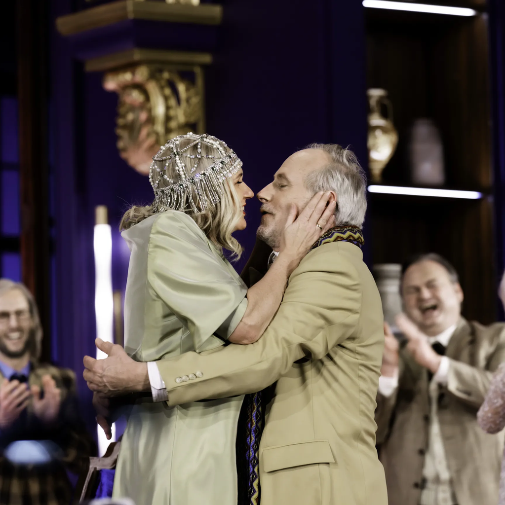

- **© ×**

  Monika Rittershaus

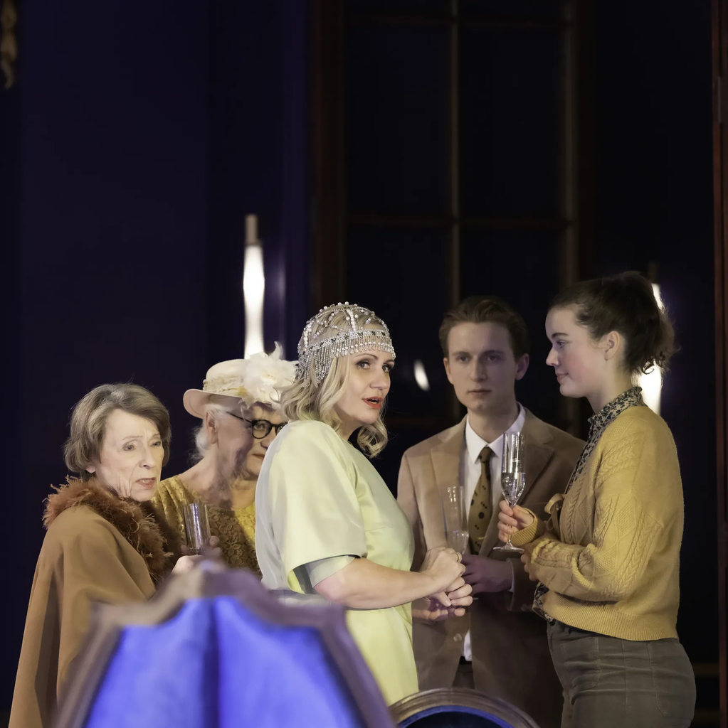

- **© ×**

  Monika Rittershaus

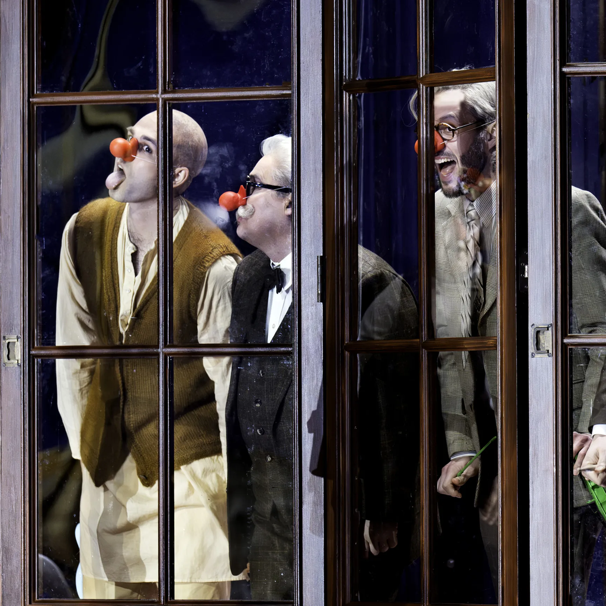

- **© ×**

  Monika Rittershaus

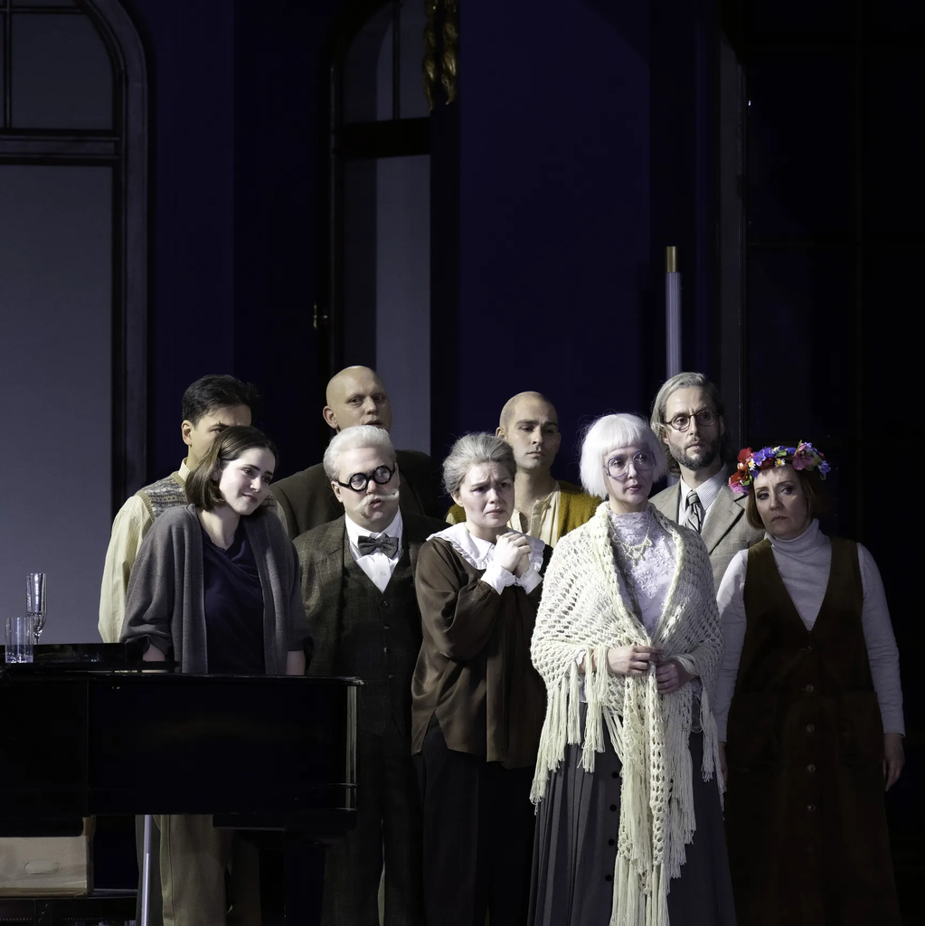

- **© ×**

  Monika Rittershaus

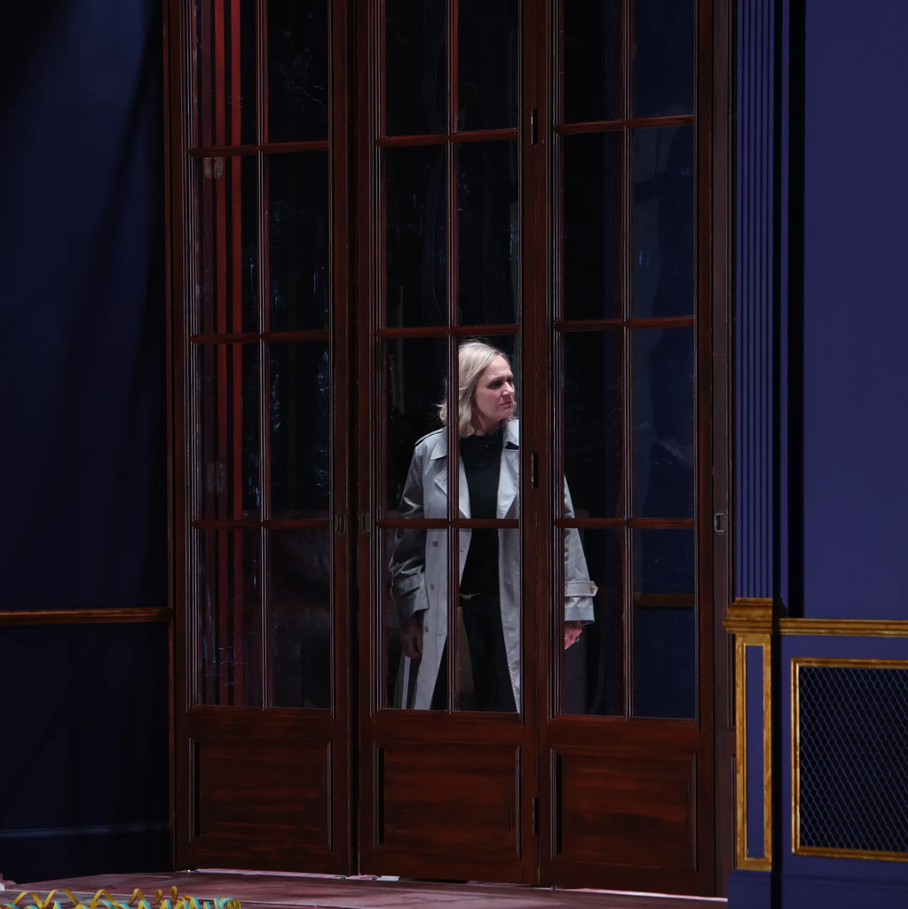

- **© ×**

  Jörg Landsberg

## Das Stück

- Spielstätte Staatsoper, Großes Haus
- Dauer 130 Min
- Altersempfehlung Ab 16 Jahren / Klasse 11
- Sprache In deutscher Sprache mit deutschen und englischen Übertiteln

Tragödie vs. Komödie! Richard Strauss und sein kongenialer Librettist Hugo von Hofmannsthal schufen mit diesem Werk eine Oper über die Welt der Oper: Ausgangspunkt der Handlung ist die Willkür eines steinreichen Kunstmäzens (ästhetisch gänzlich unbeflissen). Kurz vor der Erstaufführung eines von ihm beauftragten neuen Musiktheaterwerks ordnet er an, gleichzeitig ein Stück einer Komödiantengruppe aufzuführen. Der Komponist des neuen Werkes ist außer sich, fürchtet seinen heroischen Opernerstling durch Lächerlichkeit bedroht, kann die Verstrickung der beiden Aufführungen allerdings nicht verhindern. Ariadne auf Naxos ist der dritte für die Staatsoper Hamburg entworfene Teil der Strauss-Trilogie von Regisseur Dmitri Tcherniakov. Ihr Satyrspiel. Ihr Höhepunkt. Hier konkurrieren nicht nur zwei Liebes-, sondern auch zwei Lebensmodelle auf humorvolle, aber auch bitterernste Weise.  
Uraufgeführt wurde die Oper am 4. Oktober 1916 in der Hofoper Wien. Die Hamburger Inszenierung feierte am 26. Januar 2025 Premiere.

Rahmenprogramm

[figure not shown]

Mit FRAMING the REPERTOIRE beleuchten wir vergangene Inszenierungen als eigenständige Kunstform.

[Mehr dazu](https://www.die-hamburgische-staatsoper.de/de/ueberuns/oper/framing-the-repertoire)

- GUIDANCE: Diskutieren Sie mit jungen Expert:innen über Werk, Inszenierung und Relevanz – vor, während und nach jeder Vorstellung in den Foyers
- Gespräch: Am 4. Dezember 2025 findet nach der Vorstellung im Vorderhaus der Hamburgischen Staatsoper das Gespräch „Ästhetik: Naturalismus auf der Opernbühne“ zwischen Dr. Laura Schmidt, Prof. Sabina Dhein und Prof. David Hermann statt.

Über die Inszenierung

von Christopher Warmuth

Regisseur Dmitri Tcherniakov hat einen Faible für Rollenspiele und Rahmenhandlungen. *Ariadne auf Naxos* wird bei ihm zu einer radikalen Uminterpretation. Tcherniakov verabschiedet sich hier vom traditionellen Kunstdiskurs, zu dessen Behandlung das Werk so viele Regisseurinnen und Regisseure verleitet(e), und macht stattdessen das Leid der Ariadne selbst zum Gravitationszentrum dieses Abends. Statt eines erzählten Spiels im Spiels durch die hereinbrechende Gaukler-Truppe, erleben wir nach der Geburtstagsfeier eines glücklichen Paares das emotionale Gegenteil: den Verlust des Geliebten. Der plötzliche Tod des Mannes wird so zum Scharnier zwischen den beiden Handlungsebenen im Werk. Die Gauklertruppe wird zu einem Freundeskreis, der der verwitweten Ariadne Lebensfreude zurückgeben will. Tcherniakov kehrt die Beziehung von Figur und Hintergrund um und zeigt eine Frau, deren Trauer keine theatrale Pose bleibt, sondern schmerzhaft gegenwärtig wird. So ist *Ariadne auf Naxos* hier keine Auseinandersetzung mit der kunsttheoretischen Frage nach einer Oper in einer Oper in einer Oper, sondern eine intime, psychologisch dichte Studie über Verlust.

Tcherniakovs Regiehandschrift ist immer geprägt von einer kompromisslosen Ernsthaftigkeit im Umgang mit den Figuren. Sein Hyperrealismus bedeutet nicht bloß Detailversessenheit, sondern eine unnachgiebige psychologische Tiefenbohrung. Wo andere Regisseure oft an der Oberfläche realistischer Gesten verharren, zwingt er sein Publikum dazu, die verborgenen Mechanismen von Macht, Gewalt und Begehren mitzudenken. Er entlarvt Rollenbilder, soziale Rituale und tradierte Wahrheiten, indem er sie mit einer fast schon filmischen Präzision aufbricht und neu zusammensetzt. Gerade die Musik nutzt er dabei nicht als bloße Illustration, sondern als Motor für emotionale und psychische Schichten, die den Figuren ihre Vieldeutigkeit und Widersprüchlichkeit zurückgeben. So entstehen Inszenierungen, die nicht nur erzählen, sondern auch befragen und bloßlegen, was unter der Oberfläche verborgen liegt.

In der aktuellen Spielzeit ist an der Staatsoper Hamburg die komplette Strauss-Trilogie zu erleben, die Tcherniakov eigens für das Haus entwickelt hat: *Elektra* feierte im November 2021 Premiere, *Salome* folgte im Oktober 2023 und *Ariadne auf Naxos* im Januar 2025.

- - Musikalische Leitung [Johannes Debus](https://www.die-hamburgische-staatsoper.de/de/personen/4015-johannes-debus)

  Mit: [Wolfram Koch](https://www.die-hamburgische-staatsoper.de/de/personen/39916152-wolfram-koch), [Martin Gantner](https://www.die-hamburgische-staatsoper.de/de/personen/1155-martin-gantner), [Annika Schlicht](https://www.die-hamburgische-staatsoper.de/de/personen/2147485123-annika-schlicht), [Jamez McCorkle](https://www.die-hamburgische-staatsoper.de/de/personen/39915854-jamez-mccorkle), [William Desbiens](https://www.die-hamburgische-staatsoper.de/de/personen/39915891-william-desbiens), [Keith Klein](https://www.die-hamburgische-staatsoper.de/de/personen/39915892-keith-klein), [Anja Kampe](https://www.die-hamburgische-staatsoper.de/de/personen/5443-anja-kampe), [Nadezhda Pavlova](https://www.die-hamburgische-staatsoper.de/de/personen/39913295-nadezhda-pavlova), [Nicholas Mogg](https://www.die-hamburgische-staatsoper.de/de/personen/39913011-nicholas-mogg), [James Kryshak](https://www.die-hamburgische-staatsoper.de/de/personen/39914944-james-kryshak), [Florian Panzieri](https://www.die-hamburgische-staatsoper.de/de/personen/39914979-florian-panzieri), [Stephan Bootz](https://www.die-hamburgische-staatsoper.de/de/personen/39915917-stephan-bootz), [Olivia Warburton](https://www.die-hamburgische-staatsoper.de/de/personen/39915652-olivia-warburton), [Daniel Kluge](https://www.die-hamburgische-staatsoper.de/de/personen/39913271-daniel-kluge), [Aebh Kelly](https://www.die-hamburgische-staatsoper.de/de/personen/39915889-aebh-kelly), [Marie Maidowski](https://www.die-hamburgische-staatsoper.de/de/personen/39915888-marie-maidowski), [Georgiy Dubko](https://www.die-hamburgische-staatsoper.de/de/personen/39912207-georgiy-dubko), [Colin Aikins](https://www.die-hamburgische-staatsoper.de/de/personen/39916237-colin-aikins), [Philharmonisches Staatsorchester Hamburg](https://www.die-hamburgische-staatsoper.de/de/personen/1929-philharmonisches-staatsorchester-hamburg)

  [Details](https://www.die-hamburgische-staatsoper.de/de/programm/oper/1832-ariadne-auf-naxos)
- Zum drittletzten Mal in dieser Spielzeit
  - Musikalische Leitung [Johannes Debus](https://www.die-hamburgische-staatsoper.de/de/personen/4015-johannes-debus)

  Mit: [Wolfram Koch](https://www.die-hamburgische-staatsoper.de/de/personen/39916152-wolfram-koch), [Martin Gantner](https://www.die-hamburgische-staatsoper.de/de/personen/1155-martin-gantner), [Annika Schlicht](https://www.die-hamburgische-staatsoper.de/de/personen/2147485123-annika-schlicht), [Jamez McCorkle](https://www.die-hamburgische-staatsoper.de/de/personen/39915854-jamez-mccorkle), [William Desbiens](https://www.die-hamburgische-staatsoper.de/de/personen/39915891-william-desbiens), [Keith Klein](https://www.die-hamburgische-staatsoper.de/de/personen/39915892-keith-klein), [Anja Kampe](https://www.die-hamburgische-staatsoper.de/de/personen/5443-anja-kampe), [Lenneke Ruiten](https://www.die-hamburgische-staatsoper.de/de/personen/2147485902-lenneke-ruiten), [Nicholas Mogg](https://www.die-hamburgische-staatsoper.de/de/personen/39913011-nicholas-mogg), [James Kryshak](https://www.die-hamburgische-staatsoper.de/de/personen/39914944-james-kryshak), [Florian Panzieri](https://www.die-hamburgische-staatsoper.de/de/personen/39914979-florian-panzieri), [Stephan Bootz](https://www.die-hamburgische-staatsoper.de/de/personen/39915917-stephan-bootz), [Olivia Warburton](https://www.die-hamburgische-staatsoper.de/de/personen/39915652-olivia-warburton), [Daniel Kluge](https://www.die-hamburgische-staatsoper.de/de/personen/39913271-daniel-kluge), [Aebh Kelly](https://www.die-hamburgische-staatsoper.de/de/personen/39915889-aebh-kelly), [Marie Maidowski](https://www.die-hamburgische-staatsoper.de/de/personen/39915888-marie-maidowski), [Georgiy Dubko](https://www.die-hamburgische-staatsoper.de/de/personen/39912207-georgiy-dubko), [Colin Aikins](https://www.die-hamburgische-staatsoper.de/de/personen/39916237-colin-aikins), [Philharmonisches Staatsorchester Hamburg](https://www.die-hamburgische-staatsoper.de/de/personen/1929-philharmonisches-staatsorchester-hamburg)

  [Details](https://www.die-hamburgische-staatsoper.de/de/programm/oper/1832-ariadne-auf-naxos)
- Zum vorletzten Mal in dieser Spielzeit
  - Musikalische Leitung [Johannes Debus](https://www.die-hamburgische-staatsoper.de/de/personen/4015-johannes-debus)

  Mit: [Wolfram Koch](https://www.die-hamburgische-staatsoper.de/de/personen/39916152-wolfram-koch), [Martin Gantner](https://www.die-hamburgische-staatsoper.de/de/personen/1155-martin-gantner), [Annika Schlicht](https://www.die-hamburgische-staatsoper.de/de/personen/2147485123-annika-schlicht), [Jamez McCorkle](https://www.die-hamburgische-staatsoper.de/de/personen/39915854-jamez-mccorkle), [William Desbiens](https://www.die-hamburgische-staatsoper.de/de/personen/39915891-william-desbiens), [Keith Klein](https://www.die-hamburgische-staatsoper.de/de/personen/39915892-keith-klein), [Lenneke Ruiten](https://www.die-hamburgische-staatsoper.de/de/personen/2147485902-lenneke-ruiten), [Anja Kampe](https://www.die-hamburgische-staatsoper.de/de/personen/5443-anja-kampe), [Nicholas Mogg](https://www.die-hamburgische-staatsoper.de/de/personen/39913011-nicholas-mogg), [James Kryshak](https://www.die-hamburgische-staatsoper.de/de/personen/39914944-james-kryshak), [Florian Panzieri](https://www.die-hamburgische-staatsoper.de/de/personen/39914979-florian-panzieri), [Stephan Bootz](https://www.die-hamburgische-staatsoper.de/de/personen/39915917-stephan-bootz), [Olivia Warburton](https://www.die-hamburgische-staatsoper.de/de/personen/39915652-olivia-warburton), [Daniel Kluge](https://www.die-hamburgische-staatsoper.de/de/personen/39913271-daniel-kluge), [Aebh Kelly](https://www.die-hamburgische-staatsoper.de/de/personen/39915889-aebh-kelly), [Marie Maidowski](https://www.die-hamburgische-staatsoper.de/de/personen/39915888-marie-maidowski), [Georgiy Dubko](https://www.die-hamburgische-staatsoper.de/de/personen/39912207-georgiy-dubko), [Colin Aikins](https://www.die-hamburgische-staatsoper.de/de/personen/39916237-colin-aikins), [Philharmonisches Staatsorchester Hamburg](https://www.die-hamburgische-staatsoper.de/de/personen/1929-philharmonisches-staatsorchester-hamburg)

  [Details](https://www.die-hamburgische-staatsoper.de/de/programm/oper/1832-ariadne-auf-naxos)
- Zum letzten Mal in dieser Spielzeit
  - Musikalische Leitung [Johannes Debus](https://www.die-hamburgische-staatsoper.de/de/personen/4015-johannes-debus)

  Mit: [Wolfram Koch](https://www.die-hamburgische-staatsoper.de/de/personen/39916152-wolfram-koch), [Martin Gantner](https://www.die-hamburgische-staatsoper.de/de/personen/1155-martin-gantner), [Annika Schlicht](https://www.die-hamburgische-staatsoper.de/de/personen/2147485123-annika-schlicht), [Jamez McCorkle](https://www.die-hamburgische-staatsoper.de/de/personen/39915854-jamez-mccorkle), [William Desbiens](https://www.die-hamburgische-staatsoper.de/de/personen/39915891-william-desbiens), [Keith Klein](https://www.die-hamburgische-staatsoper.de/de/personen/39915892-keith-klein), [Nadezhda Pavlova](https://www.die-hamburgische-staatsoper.de/de/personen/39913295-nadezhda-pavlova), [Anja Kampe](https://www.die-hamburgische-staatsoper.de/de/personen/5443-anja-kampe), [Nicholas Mogg](https://www.die-hamburgische-staatsoper.de/de/personen/39913011-nicholas-mogg), N.N., [Florian Panzieri](https://www.die-hamburgische-staatsoper.de/de/personen/39914979-florian-panzieri), [Stephan Bootz](https://www.die-hamburgische-staatsoper.de/de/personen/39915917-stephan-bootz), [Olivia Warburton](https://www.die-hamburgische-staatsoper.de/de/personen/39915652-olivia-warburton), [Daniel Kluge](https://www.die-hamburgische-staatsoper.de/de/personen/39913271-daniel-kluge), [Aebh Kelly](https://www.die-hamburgische-staatsoper.de/de/personen/39915889-aebh-kelly), [Marie Maidowski](https://www.die-hamburgische-staatsoper.de/de/personen/39915888-marie-maidowski), [Georgiy Dubko](https://www.die-hamburgische-staatsoper.de/de/personen/39912207-georgiy-dubko), [Colin Aikins](https://www.die-hamburgische-staatsoper.de/de/personen/39916237-colin-aikins), [Philharmonisches Staatsorchester Hamburg](https://www.die-hamburgische-staatsoper.de/de/personen/1929-philharmonisches-staatsorchester-hamburg)

  [Details](https://www.die-hamburgische-staatsoper.de/de/programm/oper/1832-ariadne-auf-naxos)

[interactive chart not shown]